# Working Man’s Blues: How Occupational Identity Shapes Emotional Experience

Emily Maloney

**Abstract:** How does occupational identity shape emotional experience? Prior work has largely framed occupation and emotion in terms of occupational status differentials structuring the experience of powerful, negative emotions or cultural norms enforcing types of acceptable emotional expression. Complementing and building on this work by using an identity-centered approach informed by Affect Control Theory, this paper asks how being in one occupational identity versus another influences the emotions one is likely to experience in everyday life. Occupational identities generate daily interaction sets with typical others which create opportunities for identity maintenance and confirmation. When identities are confirmed, individuals feel emotions that are similar in cultural meaning to the identity. Analysis of the emotions module of the 1996 GSS finds support for the hypothesis that as emotions are further away in cultural meaning from the meaning of one’s occupational identity, they are less frequently reported as part of weekly experience. This relationship is stronger for those with more material resources, men, and older individuals, signifying that having interactional resources that aid in defining the situation allow those with more status and material resources to be more effective at maintaining their identity.

## Introduction

How does occupying an occupational identity determine which sorts of emotions an individual experiences in everyday life? Prior work has framed this question largely in terms of the relationships between the power and prestige structure and enforcement of emotion norms (Collett and Lizardo 2010; Hochschild 2012a; Kemper 1978; Lively and Powell 2016). In general, this work has focused on explaining who is more likely to experience and suppress expression of negative emotions as a consequence of the lower status of an occupation and who has to produce and manage others’ emotions as part of their work (Hochschild 2012a). This study, however, takes a more explicitly identity-centered approach to argue that one’s occupational identity shapes emotional experience by influencing the social interactions within the work environment and the emotional consequences that result from them. I hypothesize that individuals report experiencing emotions that are closer in meaning to their occupational identity more frequently than those that are less similar in cultural meaning.

Working adults spend the majority of their waking hours enmeshed in the identity associated with their job – their occupational identity (Fine 1996; Phelan and Kinsella 2009). Occupations clearly have differing levels of material rewards and requirements attached to them – the income earned, the hours worked, and the education and network ties required to attain them. But these role-identities also have different cultural meanings, namely how good the occupation is, how powerful it is, and how active they are (Freeland and Hoey 2018; Heise 2007). These meanings shape the types of interactions one has with other individuals in daily life. For example, a lawyer’s day is more likely to involve interactions with clients, other lawyers, or judges in which they are treated as an expert guiding others through a complicated legal process. These interactions, when they go well, may engender feelings of contentment or self-respect; if they go poorly, they may evoke frustration or resentment. Identity theorists have long suggested that individuals largely strive to maintain their identities through interactions (Burke and Stets 2009; Heise 2007). Doing so with regard to occupational identity means meeting the societal expectations associated with one’s job’s meaning.

Using this logic and taking a specifically Affect Control Theory approach, this paper tests the hypothesis that working adults are more likely to report feeling emotions that are close in meaning to the sentiment of their occupational identity. Further, the more material power and resources you have to help you define and control the situation, the stronger this relationship will be because you are more effective at maintaining the identity.

## Background

### Occupations and Emotions

Prior work on occupational identity and emotional experience has generated two key strands of knowledge that situate the current study. First, there is a relationship between the power and status of an individual’s occupation and their likelihood of feeling and displaying powerful negative emotions, specifically anger (Collett and Lizardo 2010; Lively and Powell 2016; Park et al. 2013). Second, for many occupations, there is an expectation that performing and managing emotions is part of one’s occupational duties (Hochschild 2012a; Lively 2000, 2002).

#### Status and Negative Emotions

There is evidence that experiencing and expressing negative emotion is connected to one’s occupational prestige and general status position. In the first case, individuals of low occupational status are likely to experience negative emotions such as anger or resentment as a result of feeling disrespected in interactions in which they have little to power over affecting outcomes (Bonilla-Silva 2019; Foy et al. 2014). Furthermore, lower status occupations tend to also be more insecure, both in terms of material benefits such as salary and benefits, but also in the hours or even days one works, all of which create stress and work-life balance conflicts, which have been linked to negative emotional and health outcomes (Schneider and Harknett 2019).

On the other hand, expressing anger toward others is typically viewed as a signal of power or authority, and thus typically reserved for individuals in high-status occupations or those in leadership positions (Collett and Lizardo 2010; Shao and Guo 2020). Along these lines, individuals are more likely to express post-event anger to someone of lower or equal status when the situation was created by a higher-status individual (Lively and Powell 2016). Individuals in lower status positions are also more often sanctioned professionally and interactionally for expressing anger towards others. A stereotype illuminating this finding is that of the “angry black woman,” a controlling image used to delegitimize the expertise and claims of black women by pathologizing their emotional expression (Harlow 2003; Wingfield 2010). In this way, extreme negative emotions may be more often experienced by lower status individuals in occupations, but only acceptably expressed by those in the higher status positions of the occupational landscape.

#### Emotional Labor

The second vein of research on occupational emotional experience views emotions as something that are managed to align with broader cultural norms around when, which, and whose display of emotions are appropriate – termed “feeling rules” (Hochschild 2012a). The classic example of this is a service worker who is expected to produce pleasant emotions and manage the emotions of customers as part of their job expectations (Ashforth and Humphrey 1993; Brotheridge and Grandey 2002; Grandey 2000; Hochschild 2012b). This work shows that to fulfill job expectations for service work positions, individuals are required to manage customers’ emotions and produce positive, calming emotions as part of their occupational expectations (producing “emotional labor”). This can lead to feelings of burnout, inauthenticity, and exhaustion, especially when there is large difference in the emotion produced because of the job requirement and the emotion felt spontaneously as a result of an interaction (Brotheridge and Grandey 2002). Notably, further work has extended the understanding of emotional labor into non-service based professions, illuminating how individuals manage emotions within professional organizations through interpersonal reciprocal acts of emotional support amongst similar-status others and management of higher-status others’ emotions within an organization (Lively 2000, 2002). Taken together, these two strands of work suggest that individuals higher in the status hierarchy may have both more leeway to express extreme emotions and the benefit of those in lower status positions deferring to their definition of the situation in order to manage their emotions.

These insights lead to two questions that motivate this paper. First: is emotional experience, beyond the bounds of powerful, negative emotions such as anger, distributed according to one’s occupational identity? If so, what explains this relationship? Second, does one’s access to material resources or social status impact the relationship between occupational identity and emotional experience? I use Affect Control Theory as the theoretical basis of the hypotheses I develop and test to answer these questions. Specifically, I argue that emotional experience is linked to the cultural meaning of an individual’s occupational identity. As individuals strive to maintain their identity in day-to-day situations, they have interactions which cause them to feel emotions that are similar in meaning to their occupational identity. Having more material resources and social status strengthens the relationship between identity and emotional experience by providing interactional resources which affect the power an individual has in controlling their interactions.

### Affect Control Theory

Affect Control Theory is a formal theory of social behavior that rests upon the fundamental principle that individuals act in ways to maintain cultural meaning. Drawing from research on how cultural meaning inheres in language and deriving from the symbolic interactionist tradition, Affect Control Theory advances the idea that words not only have cognitive or denotive meaning, but also affective meaning. For instance, while “Mother” specifically means a woman who is the parent of a child, it also has the affective meanings associated with how good we think Mothers[^1] are, how powerful Mothers are, and how active Mothers are. These three dimensions of meaning: Evaluation, corresponding to good/bad, Potency to powerful/weak, and Activity to active/inactive, cover much of the variation in affective sentiment. Affect Control Theory researchers have conducted studies in various cultures in which they have individuals rate concepts along those three dimensions, resulting in estimates of the mean Evaluation, Potency, and Activity (EPA, hereafter) of many social identities and behaviors from a scale of -4.3 to 4.3. For instance, the EPA value of Mother in the most recent ACT dictionary is (3.05, 2.66, 0.76), meaning that in the U.S., Mothers are seen as very good, very powerful, and moderately active (Smith-Lovin, Robinson, Cannon, Clark, Freeland, Morgan and Rogers 2016)[^2]. These culturally agreed-upon locations within affective space for identities and behaviors are termed fundamental sentiments; they represent the baseline cultural meaning of social terms.

In turn, Affect Control Theory argues that individuals cognitively define situations, in the form of an Actor doing a Behavior to an Object identity, and affectively react to that definition. As a result of situations, the impressions of these elements of the situation shift, due to how well the other aspects of the situation cohere with the cultural sentiment of each other (Heise and Smith-Lovin 1981). The sentiments of elements of a situation after an event have occurred are called the transient impressions of the Actor, Behavior, and Object. The affective control principle of the theory hinges on the difference between transient impressions and the fundamental sentiments for the elements of the situation. The deflection, or the sum of squared differences between the transient and fundamental E, P, and A values of the actor, behavior, and object, is the indicator of cultural (dis)confirmation. Higher deflection scores indicate more movement within the three-dimensional affective space, and as a result, are more culturally unlikely and unexpected (Heise and Mackinnon 1987). As an indication of affective movement, deflection is considered an emotional sense of unsettlement or anxiety about the situation and prompts individuals in a situation to act in such a way as to decrease deflection as much as possible.

### Emotions in ACT

Affect Control Theory involves affect both broadly as cultural sentiments, situational impressions of identities and actions, and as specifications of feelings that result as a consequence of events. The latter feelings are considered to be “situationally episodic and ephemeral affective experiences we call emotions” (MacKinnon 1994:123). Just as identities and behaviors exist in EPA space, so do words that indicate emotions such as Annoyed, which is bad, slightly weak, and slightly active (-2.08, -0.57, 0.53) or Proud, which is good, powerful, and moderately active (2.17, 2.28, 1.15).

In a similar way to the estimation of the impression formation equations that suggest what affects post-event impressions, Averett and Heise (1987) estimated attribution equations that predicted emotional attributions for the Actor or Object that “would combine with a known identity to make sense of an observed social event” (Robinson and Smith-Lovin 1999:78). Flipping the understanding of these attribution equations from how observers would expect an actor or object to feel after an event to predicting emotional expression following an interaction, these attribution equations came to be the emotion equations (Averett and Heise 1987; Heise and Thomas 1989; MacKinnon 1994).

These equations suggest that emotions are the product of two elements: the deflection, or how different the transient impressions are from the fundamental sentiments, and the transient impression of the actor or object in question (MacKinnon 1994; Robinson and Smith-Lovin 2006). This exemplifies that the fundamental sentiment itself matters in predicting the likelihood of certain emotions. If there is very little or no deflection, the transient impression will be equal to the fundamental sentiment and the Actor or Object will be predicted to feel an emotion that is similar in EPA to its identity’s fundamental sentiment (Robinson and Smith-Lovin 2006). This type of emotion is called a *characteristic emotion*, and it occurs in situations in which identities are perfectly confirmed.

This means that identities which are higher in evaluation have characteristic emotions that are similarly high in evaluation – e.g. some characteristic emotions of a Child are Elated and Amused (MacKinnon 1994). Conversely, identities that are not socially valued or powerless will feel corresponding emotions when their identities are confirmed – e.g. an Alcoholic (-2.03, -1.99, -0.09) will feel Humiliated or Hurt when his stigmatized identity is perfectly confirmed.

### Occupational Identity and Emotion

Adults who work full-time spend the majority of their day-time hours within their occupational identity. Through embodying this identity, individuals will strive to enact behaviors within interactions that will maintain the fundamental sentiment of their occupational identity. Further, because Affect Control Theory predicts that individuals feel emotions that are close in meaning to an identity when an identity is confirmed through an interaction, we should expect that individuals in occupational identities report feeling emotions that are similar to the characteristic emotion of their identity. Moreover, the institutional frameworks that structure the types of interactions an individual will have while occupying their occupational identity provide them with interaction sets that, in general, should work to maintain that identity (Ridgeway 2000). For example, pediatricians spend the majority of their occupational hours interacting with children and their parents in a doctor-patient relationship. Most of the interactions will fundamentally be of the type Doctor Helps Patient which maintains the identity of the doctor in that situation. If institutional frameworks did not sustain identity maintaining interactions in this way, we would expect more volatility in the EPA ratings of identities and behaviors. Alternatively, we would expect evidence of cultural change in the fundamental EPA of those identities and behaviors. Given this, the first hypothesis argues that individuals should be likely to report experiencing emotions that are close in meaning to their occupational identity’s characteristic emotion.

**H1**: The greater the distance between an individual’s occupational identity’s characteristic emotion and an emotion word in EPA space, the less likely that individual is to report frequently feeling that emotion.

**H2**: The larger the average distance between an emotion and occupational identity characteristic emotions, the less often employed individuals will report feeling that emotion on average.

### Resources

However, one important consideration to take into account when evaluating hypothesis one is that individuals hold many identities throughout their daily lives, not just their occupational identity. Furthermore, people do not always get to control the situations they are put into or the actions of their interaction partners, and this can depend on the power they hold. For instance, in some cases, a Police Officer is able to define a situation by labeling another person a Criminal, even when the person who is being apprehended sees themselves as a Citizen or an Innocent Bystander. The officer gets that power both from the institutional resources of the position and the literal force of having weapons. Similarly, the ability of the citizen to resist such a definition may depend on his or her material resources. A Surgeon can probably reassert a Citizen or Bystander identity more easily than a Teenager. Following from this, we would expect that the ability to define situations and have interaction partners who work to maintain one’s definition of the situation is not equal across people, but rather a consequence of the material power one holds in daily life (Heise 2020). This power can be garnered through access to material, cultural and interpersonal resources, such as status, dress, manner, scripts, level of education, and self-esteem (Miles 2014; Stets and Cast 2016).

Another possibility is that individuals with more material power have occupational identities that are more salient within their entire set of identities and thus more important to their baseline sense of self than those with lesser material resources (Alvesson and Robertson 2006; Miles 2014). Because material resources and types of occupational identity are clearly correlated, this may mean that those who have high status occupations find the maintenance of them more necessary for the maintenance of their overall sense of self, causing them to control their interactions within the occupational identity to a higher degree. Furthermore, their interactions outside of their occupation may more closely match those within it, compared with those who have less material power. Both of these processes would lead us to expect that those who have more material and social power will be more effective at shaping situations to ensure that they experience emotions closer to the characteristic meaning of their occupational identity. Therefore, the third hypothesis predicts a statistical interaction between material power and the relationship between occupational identity and emotional experience.

**H3**: The negative relationship between distance from emotion and frequency of experiencing the emotion will be stronger for those who have more material power.

### Diffuse Status Characteristics: Gender, Race, and Age

Social resources may also play a role in impacting the relationship between distance and frequency of emotion. One important type of social resource is the diffuse status characteristics an individual possesses. Similar to how material resources function, diffuse status characteristics – most notably – gender and race, impact interactions by providing a status framework by which they proceed (Ridgeway 2011). Because people automatically categorize others that they interact with in terms of sex, race, and age – these cultural frames organize social interactions to uphold status beliefs that one social category (white individuals, men, and older people) is more competent, affording them both more influence over the interaction (Ridgeway and Kricheli-Katz 2013). In the case of identity maintenance, this suggests that individuals with valued diffuse status characteristics gain interactional resources from these status beliefs, giving them more control over defining the situation in such a way as to confirm their identity.

**H4**: The negative relationship between distance from emotion and frequency of experiencing the emotion will be stronger for men than for women.

**H5**: The negative relationship between distance from emotion and frequency of experiencing the emotion will be stronger for white individuals than non-white individuals.

**H6**: The negative relationship between distance from emotion and frequency of experiencing the emotion will be stronger the older the respondent.

### Data

The Affect Control Dictionary used for measurements of the cultural meaning of the occupational identities and emotion words in this analysis was the most recent U.S. dictionary, measured in 2015 with a sample of respondents from the University of Georgia, Duke University, and the Durham, North Carolina community (Robinson et al 2016). These identities and modifiers were measured by asking respondents to rate a single Identity or Emotion word at a time on how good/bad, powerful/weak, and active/inactive they were, on a scale from -4.3 (extremely bad, weak, inactive) to +4.3 (extremely good, powerful, active). The mean rating across respondents on each axis is used as the point estimate for the identity or behavior.

#### Variables

##### Independent Variables

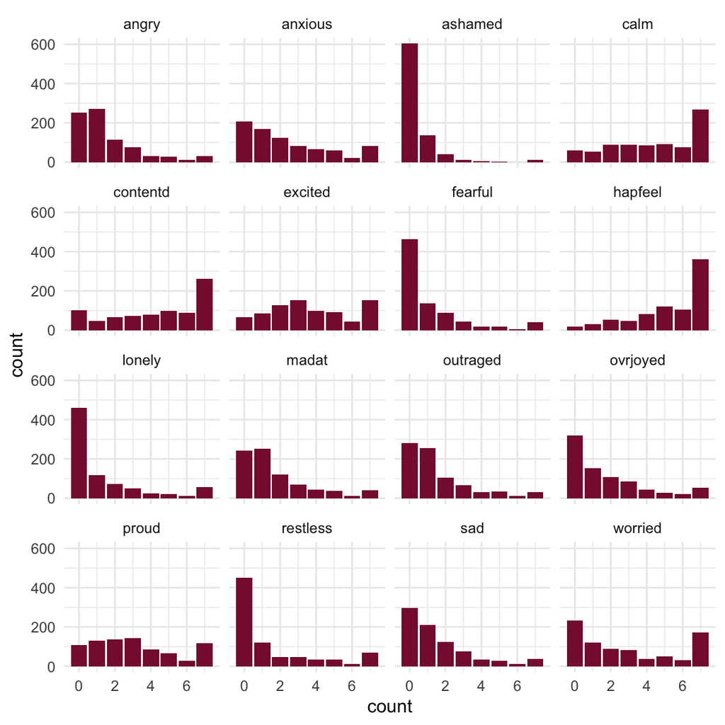

Distributions of Emotion Counts

The primary independent variable tested in this analysis is the distance between the EPA meaning of the characteristic emotion of each respondent’s occupational identity and the meaning of each of the GSS emotions. To calculate this distance, every occupation in the International Standard Classification of Occupations from 1988 (ISCO-88) was assigned a matching occupational identity using a crosswalk, which pairs each occupational code originally in the GSS with an identity from the ACT dictionary used in this analysis (Freeland and Hoey 2018). The crosswalk used in this analysis is based on the same crosswalk used by Freeland and Hoey (2018), with some expansion. The full crosswalk and the rules used to match occupation codes to occupational identities are included in the supplemental appendix to this paper. The crosswalk resulted in a total of 102 unique occupational identities occupied by the 816 respondents. The characteristic emotion for each occupational identity was calculated using Interact, an ACT simulation program written by Heise (2007). Finally, the Euclidean distance between the EPA of each occupational identity’s characteristic emotion and the EPA of each GSS emotion was calculated. This distance was then standardized for the analysis, such that the mean is zero and standard deviation one, to help with model convergence and model interpretability.

Table 1: Distances from Characteristic Emotion by Emotion DV

| Emotion | Mean | Standard Deviation |
| --- | --- | --- |
| angry | 17.573 | 3.869 |
| anxious | 22.443 | 7.863 |
| ashamed | 31.286 | 7.759 |
| calm | 13.204 | 3.843 |
| contented | 4.757 | 2.325 |
| excited | 4.673 | 2.932 |
| fearful | 30.067 | 8.553 |
| happy | 5.943 | 4.125 |
| lonely | 43.629 | 10.283 |
| mad | 18.909 | 5.606 |
| outraged | 18.535 | 4.130 |
| overjoyed | 6.894 | 4.192 |
| proud | 2.501 | 2.377 |
| restless | 17.221 | 6.580 |
| sad | 37.674 | 10.159 |
| worried | 27.753 | 7.971 |

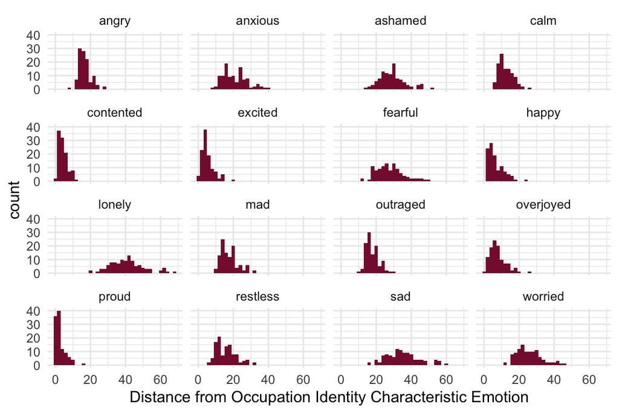

Distance from Characteristic Emotions to GSS Emotions

The second independent variable of interest is a measure of material power, created as a composite variable of each respondent’s income (logged), education level in years, father’s socioeconomic status (standardized), and occupational prestige score using a confirmatory factor analysis (Rosseel 2012). Income corresponds to a respondent’s family income, scaled to be consistent across waves and logged in the following analysis (for how realinc was computed: Ligon 1989). Education level is a numeric variable corresponding to the number of years of schooling the respondent had completed. Father’s socioeconomic status is an index computed by the GSS corresponding to the respondent’s father’s socioeconomic position and standardized for this analysis. Finally, the respondent’s occupational prestige score is the score resulting from the GSS’s measure of the “social standing” of their occupation. Table 2 displays descriptive information about these indicator variables.

Descriptive Statistics CFA Indicator Variables

|  | Mean | SD | Minimum | Maximum |
| --- | --- | --- | --- | --- |
| Father SEI | 0.000 | 1.000 | -1.701 | 2.278 |
| Education (years) | 13.935 | 2.689 | 0.000 | 20.000 |
| Income (log) | 10.244 | 0.782 | 5.894 | 11.460 |
| Occupational Prestige Score | 44.574 | 13.767 | 17.000 | 86.000 |

One assumption of a CFA is that the indicator variables are normally distributed. These variables were assessed for their normality and found to be acceptable; however, after income was logged, there remains some negative skew and father’s socioeconomic status has a slight positive skew. Skewness scores and histograms of these four variables are in the appendix to this paper.

The model was estimated using full information maximum likelihood, to make use of as much of the data as possible, without needing to remove cases that did not have missing data on all of the variables. As such, the model was estimated using 1656 respondents. The sample size for the CFA is larger than the final analysis, because individuals who were not asked the emotion questions were included in the CFA for more statistical power and sensitivity. Model fit statistics are presented in Table 3. The CFI (0.98) and TLI (0.94) were both above 0.9, indicating good but not perfect model fit. Similarly, the root mean squared error (RMSEA) is acceptable, at 0.078 with a confidence interval of (0.047, 0.109).

Fit Measures for CFA

| measure | amount |
| --- | --- |
| AIC | 27653.360 |
| BIC | 27718.298 |
| CFI | 0.981 |
| RMSEA | 0.078 |
| RMSEA Confidence Interval High | 0.109 |
| SRMR | 0.020 |
| TLI | 0.942 |

CFA Factor Loadings

| Latent Factor | Indicator | B | SE | Z | p-value | Beta |
| --- | --- | --- | --- | --- | --- | --- |
| Material Power | log_Income | 1.000 | 0.000 | NA | NA | 0.450 |
| Material Power | Dad SEI | 1.155 | 0.112 | 10.339 | 0 | 0.407 |
| Material Power | Education (years) | 5.975 | 0.462 | 12.940 | 0 | 0.782 |
| Material Power | Occupational Prestige | 27.804 | 1.891 | 14.704 | 0 | 0.711 |

##### Control Variables

Across the models, three various demographic and corresponding variables were included as controls: race, sex, and age. These variables are included as controls in the following models because there is reason to believe that they could affect both selection into occupational category as well as the probability of the respondent reporting certain emotions. Race was operationalized as a factor variable with three levels: white, black, and other. Male is a binary variable with a level of one indicating the respondent identified themselves as male and 0 as female, and age is a numeric variable indicating the number of years old the respondent is at the time of the survey.

Descriptive statistics for the independent and control variables are shown in Table 5. The sample is slightly more male than female, and overwhelmingly white – only 20% of respondents are not white. Age ranges from 19 to 78, with respondents averaging around 40 years old.

Descriptive Statistics

| **Characteristic** | **N = 816** |
| --- | --- |
| Age | 40 (12), (min: 19, max: 78) |
| Material Power | 0.00 (0.31), (min: -0.76, max: 0.93) |
| Sex |  |
| Female | 379 (46%) |
| Male | 437 (54%) |
| Race |  |
| White | 657 (81%) |
| Black | 116 (14%) |
| Other | 43 (5.3%) |

#### Analysis

Model four tests H3 by including an interaction between the measure of material power and the distance from emotion. Model five tests H4 by including an interaction between sex and the distance from emotion. Model six tests H5 by including an interaction between race and the distance from emotion. Lastly, model seven tests H6 by including an interaction between age and the distance from emotion.

#### Results

The results from model two indicate that this effect remains negative and significant even after material power is added to the model, suggesting that regardless of one’s resources, EPA distance from an occupation’s characteristic emotion remains an important deterrent from experiencing that emotion. Interestingly, material power on its own has no direct effect on the emotion counts. Further, when all other controls are added in model three, distance from emotion remains both negative and significant, only slightly lower in magnitude than in model one. To provide an illustrative example: when everything else is held constant at its mean, we would expect that an individual whose occupational identity’s characteristic emotion is located at the mean distance from the emotion in EPA space (zero on the standardized scale) to report experiencing an emotion

[output not shown]

fewer days of the week, on average across individuals and emotions. Looking at emotions separately, I predict that for an individual whose characteristic emotion is 1 standard deviation away from “happy” in EPA space, they will report feeling the emotion

[output not shown]

fewer days than someone whose distance from happy in EPA space is at the mean. Although the magnitude of the effect is small, it is significant. In the following models I explore the hypotheses suggesting that the small size of the effect could be due to the variation in this effect across material resources and status characteristics.

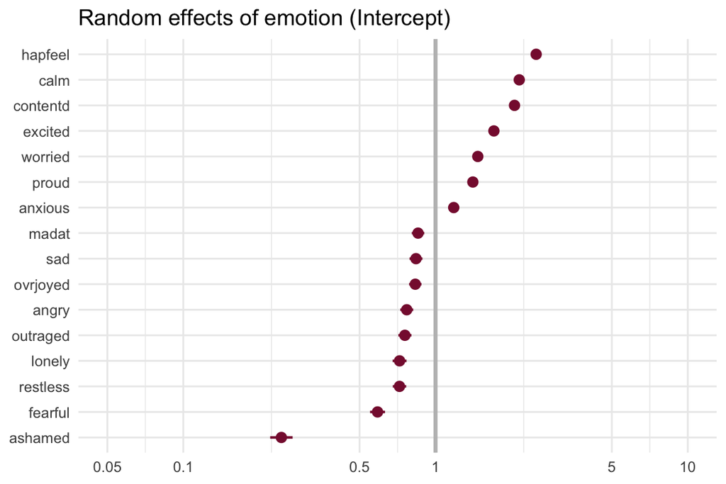

Random Intercepts for Emotions

Model four includes the interaction between the distance from emotion and material power. The coefficient for the interaction term is significant and negative. This indicates that the relationship between an individuals’ distance from an emotion and the likelihood of experiencing that emotion is dependent on how much material power they hold in a situation. The relationship is stronger when an individual has more material power. We expect that holding everything else constant, an individual will report experiencing an emotion less the further away it is from their occupational identity’s characteristic emotion, and that this decrease in expected count will be larger the more material resources they have at their disposal. In fact, given that the main effect is now not significant, this indicates that *only* those with material power are able to influence that relationship.

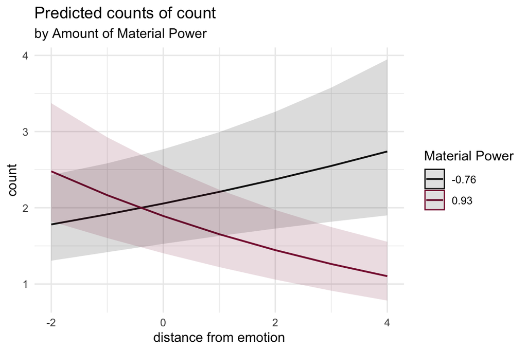

Predicted Emotion Counts

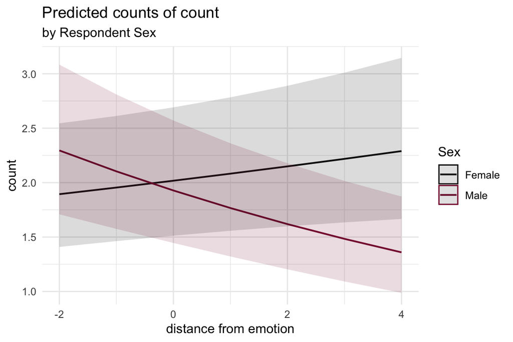

Predicted Emotion Counts

Model 7 includes an interaction term to test H6, the hypothesis about the status characteristic of age. The interaction between age and distance from emotion is significant and negative, which supports the hypothesis that as one gets older, the relationship between distance from emotion and frequency of experiencing the emotion is stronger.

Although the long format of the data and using a metric of distance from an individual occupational identity’s characteristic emotion nicely tests the central hypotheses, it obscures how exactly the predictions look different for individuals whose occupational identities are in diverse EPA spaces. To provide a few illustrative examples, table 8 shows predicted levels of emotions for an individual who is a Firefighter(3.27, 2.85, 2.29); Bill Collector (-1.07, 1.63, 1.02); and a Professor(1.83, 2.27, 0.24). Because these occupational identities exist in different places in EPA space, they are fairly different distances from the emotion words in question, which is shown in the different predictions across emotions. I use model 7 to predict these values, and hold everything else at the mean. Bill Collectors are predicted to experience the negative emotions the most (angry, outraged) while Firefighters are predicted to experience positive emotions the most (excited, happy).

Predicted Emotions for 3 Occupations

| emotion | firefighter | billcollector | professor |
| --- | --- | --- | --- |
| angry | 1.481 | 1.634 | 1.521 |
| anxious | 2.129 | 2.372 | 2.215 |
| ashamed | 0.401 | 0.460 | 0.432 |
| calm | 4.361 | 4.305 | 4.538 |
| contentd | 4.486 | 4.458 | 4.598 |
| excited | 3.854 | 3.723 | 3.797 |
| fearful | 0.978 | 1.119 | 1.040 |
| hapfeel | 5.625 | 5.349 | 5.602 |
| lonely | 1.037 | 1.212 | 1.131 |
| madat | 1.603 | 1.780 | 1.659 |
| outraged | 1.451 | 1.594 | 1.480 |
| ovrjoyed | 1.869 | 1.780 | 1.832 |
| proud | 3.187 | 3.142 | 3.196 |
| restless | 1.368 | 1.502 | 1.415 |
| sad | 1.280 | 1.474 | 1.382 |
| worried | 2.508 | 2.858 | 2.648 |

In summary, the primary hypothesis was supported by this analysis: in general, the further away an emotion is in EPA space from one’s occupational identity’s characteristic emotion, the less often an individual will report experiencing it. However, this relationship is very different depending on the level of material and status resources one has to control one’s interactions in daily life. In particular, those with more material resources, men, and older individuals all have a stronger relationship, and in some instances, the pattern is actually reversed for those with fewer resources at hand, who may end up having to defer to other’s definition of the situation, causing them to experience emotions far from their occupational status’ characteristic emotion.

### Discussion

As individuals move through interactions in their daily life, they try to confirm their identities (Burke and Stets 2009; MacKinnon 1994). This means that they try to act in ways that are expected for their given and salient identities, in order to get feedback from others and themselves that they are meeting cultural expectations and that interactions are proceeding as expected. Affect Control Theorists posit that when individuals confirm these identities, they are likely to feel emotions that are similar in meaning to the identity being enacted through the situation. This has implications for the inequality of emotional experience and expression across domains of life, as those who occupy identities that are more or less good or more or less powerful may be more likely to feel emotions of similar sentiment. In this paper, emotional experience as tied to occupational identity in particular was tested.

Overall, the results support the hypothesis that individuals are more likely to report experiencing emotions that are close in meaning to one’s occupational identity than those that are further away, even when accounting for the average reported experience of an emotion. However, the relationship is different depending on the amount of material and social resources one has at hand to define a situation and to have others work to maintain your definition of the situation. In addition to generating more evidence supporting the tight link between identity and emotion, this project also advances the notion that inequalities in occupational status not only have material consequences in terms of more income and economic stability, but also social-psychological consequences of emotional experience. In this way, this paper joins the discussion broadening the consequences of a stratified occupational landscape.

Theoretically, this paper supports Affect Control Theory’s emotion predictions and also adds some evidence to the ongoing debate between Identity Control Theory and Affect Control Theory’s diverging predictions on emotional experience. Identity Control Theory suggests that individuals should report feeling good emotions anytime they feel an identity has been confirmed, regardless of the identity’s meaning while Affect Control Theory predicts that individuals will feel emotions similar in meaning to their identity. An example of these diverging predictions would be in the case that an individual fulfills an identity that is devalued and weak – ICT predicts that an individual would feel good because an identity has been confirmed and ACT predicts that the individual feels a bad, weak emotion, such as shame (Burke 1991; Robinson, Smith-Lovin, and Wisecup 2006). Given that the evidence here supports a valence-neutral hypothesis about emotional experience – not that individuals will not feel bad emotions, but rather that emotions that are similar in cultural meaning to one’s occupational identity are more likely to be felt – these largely support Affect Control Theory’s model of emotional experience.

In terms of prior work on the intersection of emotion and experience, this paper provides a different lens through which to view the link: identity, which has been shown to helpfully bridge structural and cultural explanations of emotional experience in the past (Collett and Lizardo 2010; Lively and Powell 2016). While the results found here cannot explain all of the questions left open in previous work on emotions on the job, it affords a general framework to use when thinking about how occupations shape one’s emotional experience. For instance, when thinking about emotional labor and emotion management, concepts such as feeling rules and emotion norms could be formalized by using Affect Control Theory’s measurement tools which can quantify cultural expectations (Freeland and Hoey 2018; Hunzaker 2016).

Additionally, the results indicating the influence of material and social interactional resources supports prior work on how resources aid in interaction management and defining the situation, and provide impetus for further work on how exactly these mechanisms work as situations unfold. In particular, this work suggests that fruitful avenues of research investigate whether definition of the situation is taken by the higher status person or given thorugh deference actions of the lower status individual. Additionally, future work could look at which resources are more or less effective at maintaining an interaction and how different resources work together to maintain a situation.

#### Limitations

There are several limitations of the research design to make note of. First, the operationalization of the dependent variable as self-reports of how often the respondent felt an emotion in the past week means it is difficult to tease apart whether the dependent variable is accurately measuring an emotion experienced versus those that the respondent feels comfortable reporting having experienced.

Additionally, the variables for race and gender are not exhaustive, as those who were not white or Black were lumped into a third “Other” category and there were no questions about gender identity. This weakened the ability to test the hypotheses about diffuse status characteristics and suggests follow up work with a more targeted sample that includes more options for gender and race would be especially useful to diving deeper into these patterns. On this note, there was not enough power to include tests of intersectional effects – how might identity maintenance and corresponding emotional experience look for black versus white women, or disabled black men versus able bodied black men?

Lastly, only 102 occupational identities were included in this analysis, and they were matched via a crosswalk that tied similar, but not exactly the same, identities to GSS occupational codes. Further work that gets EPA measurements of all of the GSS occupational codes would be helpful in ensuring that these results apply across the occupational spectrum, even when small differences between occupational identity meaning is included, e.g. the difference between physician’s assistant and pediatrician.

[^1]: Mother is capitalized to follow the Affect Control Theory tradition when indicating a measured identity. All references to measured identities, behaviors, and emotions will be capitalized.
[^2]: All EPA measurements referenced in this paper come from this dictionary.